# GSE136831 IPF Lung PreProcessing

Kendrix Kek

2025-10-31

```r
library(here)
library(DT)
library(GEOquery)
library(crayon)
library(RColorBrewer)
library(tidyverse)
library(Seurat)
library(SeuratData)
library(Azimuth)
library(patchwork)
library(Matrix)
library(RCurl)
library(scales)
library(clustree)
library(SoupX)
library(cowplot)
library(metap)
library(SingleCellExperiment)
library(DropletUtils)
library(AnnotationHub)
library(HGNChelper)
library(ensembldb)
library(multtest)
library(glmGamPoi)
library(pbapply)
library(data.table)
library(ggrepel)
library(ggpubr)
library(stringr)
library(canvasXpress)
library(clinfun)
library(GGally)
library(factoextra)
library(DESeq2)
library(limma)
library(fgsea)
library(org.Mm.eg.db)
library(kableExtra)
```

## Step 1: Data Exploration and Object Creation

### Step 1.1: Create Seurat object

```r
# Read in count and the supplementary files.
mat <- readMM(file = "Z:/Kendrix/IPF_Lung/GSE136831/raw_data/GSE136831_RawCounts_Sparse.mtx.gz")
barcodes <- read.delim("Z:/Kendrix/IPF_Lung/GSE136831/raw_data/GSE136831_AllCells.cellBarcodes.txt.gz",
                       header = FALSE)
genes <- data.table::fread("Z:/Kendrix/IPF_Lung/GSE136831/raw_data/GSE136831_AllCells.GeneIDs.txt.gz",
                           data.table = FALSE)

# Define rownames using genes and colnames using barcoses.
dim(mat) # 45947 rows, 312928 columns
nrow(genes) # 45947 rows.
nrow(barcodes) # 312928 rows.

rownames(mat) <- genes$HGNC_EnsemblAlt_GeneID
colnames(mat) <- barcodes$V1

# Create Seurat object.
obj <- CreateSeuratObject(counts = mat)

# Save Seurat object as RDS object.
saveRDS(object = obj, file = "Z:/Kendrix/IPF_Lung/GSE136831/processed_data/init_seurat_obj.rds")
```

```r
# Remove unneeded objects.
rm(mat, barcodes, genes)
```

### Step 1.2: Pull sample metadata from GEO

```r
# Pull metadata from GEO.
metadata <- pData(getGEO(GEO = "GSE136831", GSEMatrix = TRUE)[[1]])
```

```
## Found 1 file(s)
```

```
## GSE136831_series_matrix.txt.gz
```

```r
# Subset only columns that we need.
colnames(metadata)
```

```
##  [1] "title"                   "geo_accession"
##  [3] "status"                  "submission_date"
##  [5] "last_update_date"        "type"
##  [7] "channel_count"           "source_name_ch1"
##  [9] "organism_ch1"            "characteristics_ch1"
## [11] "characteristics_ch1.1"   "characteristics_ch1.2"
## [13] "characteristics_ch1.3"   "treatment_protocol_ch1"
## [15] "molecule_ch1"            "extract_protocol_ch1"
## [17] "extract_protocol_ch1.1"  "taxid_ch1"
## [19] "data_processing"         "data_processing.1"
## [21] "data_processing.2"       "data_processing.3"
## [23] "data_processing.4"       "data_processing.5"
## [25] "data_processing.6"       "data_processing.7"
## [27] "data_processing.8"       "data_processing.9"
## [29] "data_processing.10"      "data_processing.11"
## [31] "platform_id"             "contact_name"
## [33] "contact_laboratory"      "contact_department"
## [35] "contact_institute"       "contact_address"
## [37] "contact_city"            "contact_state"
## [39] "contact_zip/postal_code" "contact_country"
## [41] "data_row_count"          "instrument_model"
## [43] "library_selection"       "library_source"
## [45] "library_strategy"        "relation"
## [47] "relation.1"              "supplementary_file_1"
## [49] "supplementary_file_2"    "supplementary_file_3"
## [51] "supplementary_file_4"    "age:ch1"
## [53] "disease:ch1"             "Sex:ch1"
## [55] "tissue:ch1"
```

```r
metadata <- (metadata %>% subset(select = c(title,
                                            geo_accession,
                                            source_name_ch1,
                                            organism_ch1,
                                            characteristics_ch1.1,
                                            characteristics_ch1.2,
                                            characteristics_ch1.3)) %>%
               dplyr::rename(orig.ident = title,
                             tissue = source_name_ch1,
                             organism = organism_ch1,
                             condition = characteristics_ch1.1,
                             sex = characteristics_ch1.2,
                             age = characteristics_ch1.3))

# Edit some metadata variables.
metadata$orig.ident <- gsub(" scRNAseq", "", metadata$orig.ident)
metadata$condition <- gsub("disease: ", "", metadata$condition)
metadata$sex <- gsub("Sex: ", "", metadata$sex)
metadata$age <- gsub("age: ", "", metadata$age)

# Visualize preliminary distribution of sample metadata.
colnames(metadata)
```

```
## [1] "orig.ident"    "geo_accession" "tissue"        "organism"
## [5] "condition"     "sex"           "age"
```

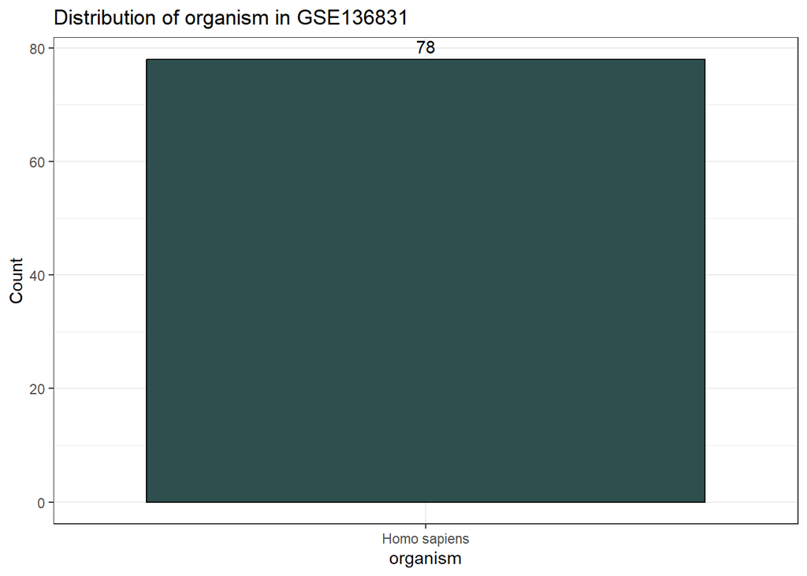

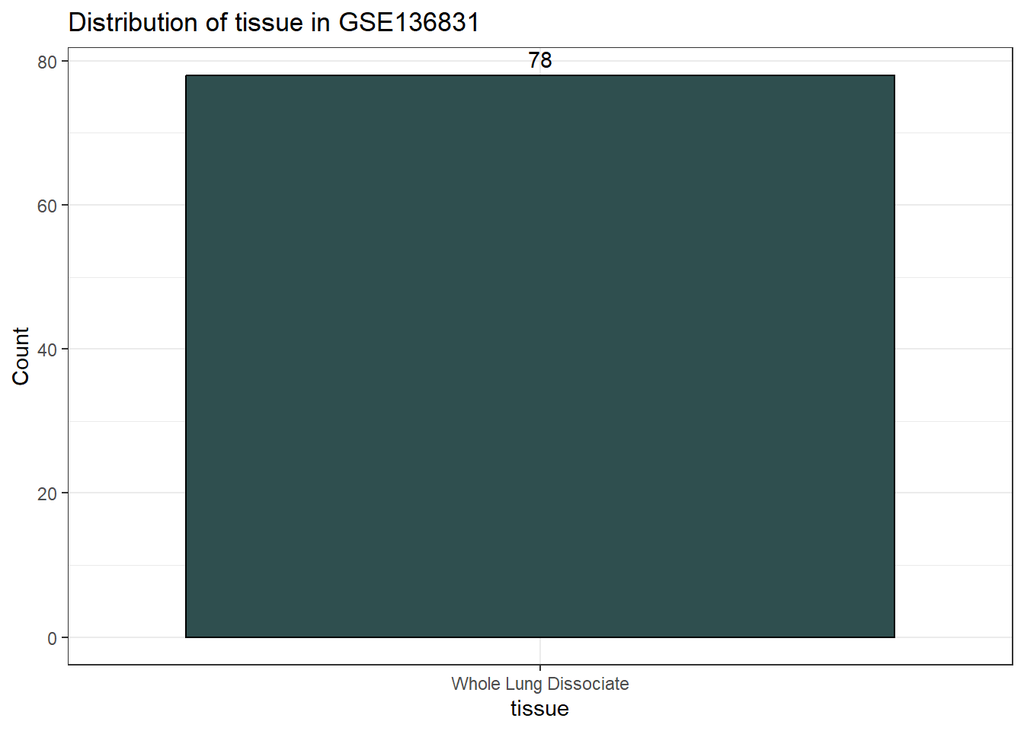

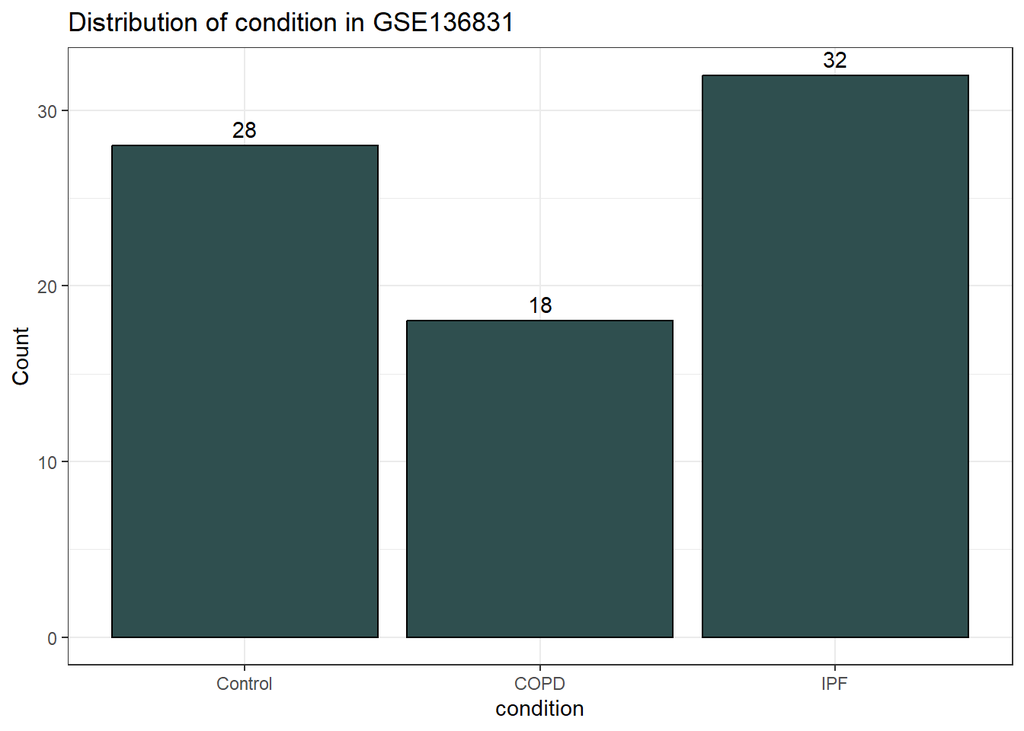

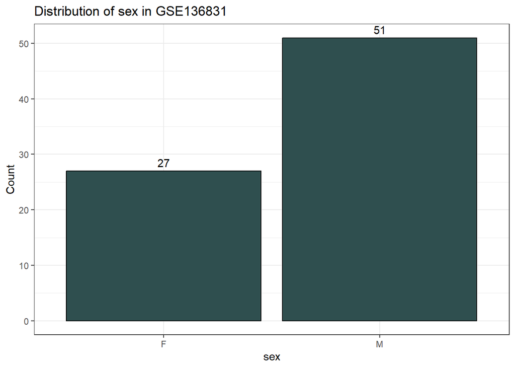

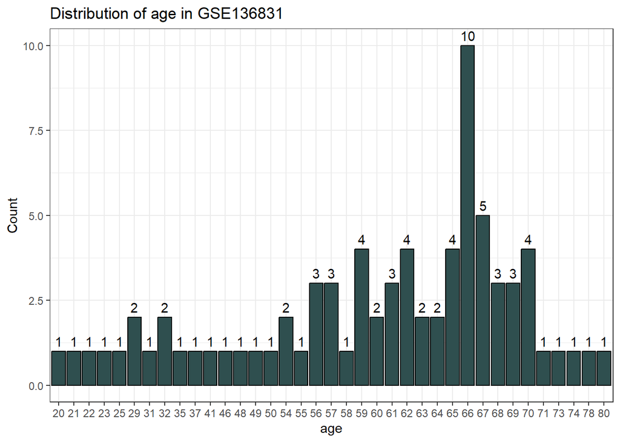

```r
columns_incl <- c("organism", "tissue", "condition", "sex", "age")

for (col in columns_incl) {
  p <- ggplot(metadata, aes_string(x = col)) +
    geom_bar(fill = "darkslategrey", colour = "black") +
    geom_text(stat = "count", aes(label = after_stat(count)), vjust = -0.5) +
    labs(title = paste("Distribution of", col, "in GSE136831"),
         x = col,
         y = "Count") +
    theme_bw()

  print(p)
}
```

```r
# Remove unneeded objects.
rm(col, columns_incl, p)
```

### Step 1.3: Pull Seurat generated metadata

```r
# Load Seurat object.
obj <- readRDS(file = "Z:/Kendrix/IPF_Lung/GSE136831/processed_data/init_seurat_obj.rds")

# Pull Seurat metadata.
seu_metadata <- obj@meta.data %>% rownames_to_column()

# Extract sample identifier to match GEO metadata.
seu_metadata$orig.ident <- ""
seu_metadata$orig.ident <- str_extract(seu_metadata$rowname, "^[^_]+")
seu_metadata$orig.ident <- sub("-.*", "", seu_metadata$orig.ident)
```

### Step 1.4: Merge both metadatas together

```r
# Merge metadata to seu_metadata by orig.ident.
meta <- left_join(seu_metadata, metadata, by = "orig.ident")

# Add rownames back to dataframe.
meta <- meta %>% column_to_rownames()
seu_metadata <- seu_metadata %>% column_to_rownames()

# Check if the row orders are maintained.
identical(rownames(meta), rownames(seu_metadata)) # TRUE.
```

```
## [1] TRUE
```

```r
identical(rownames(meta), colnames(obj)) # TRUE.
```

```
## [1] TRUE
```

```r
# Rename quality metrics columns.
meta <- meta %>% dplyr::rename(nUMI = nCount_RNA,
                               nGene = nFeature_RNA)

# Add more quality metrics.
meta$mitoRatio = PercentageFeatureSet(object = obj, pattern = "^mt-")
meta$mitoRatio = meta$mitoRatio / 100

# Calculate novelty score.
meta$log10GenesPerUMI <- log10(meta$nGene) / log10(meta$nUMI)

# Add the new metadata back to the Seurat object.
identical(rownames(meta), colnames(obj)) # TRUE.
```

```
## [1] TRUE
```

```r
identical(rownames(meta), rownames(obj@meta.data)) # TRUE.
```

```
## [1] TRUE
```

```r
obj@meta.data <- meta
```

### Step 1.5: Preliminary QC

There are some NAs introduced from the join term. Let’s find out what they are.

```r
# Find the rows with NAs.
nrow(obj@meta.data[!complete.cases(obj@meta.data),]) # 13,752 rows with NAs.
```

```
## [1] 13752
```

```r
# Which identifiers are responsible for these NAs.
unique(obj@meta.data[!complete.cases(obj@meta.data),]$orig.ident) # 022C, 92C, 210CO, 219C - looks like 3 controls and 1 COPD.
```

```
## [1] "022C"  "92C"   "210CO" "219C"
```

```r
# See if we find these in the metadata downloaded from GEO.
missing_ident <- unique(obj@meta.data[!complete.cases(obj@meta.data),]$orig.ident)
for (i in missing_ident) {
  ifelse(i %in% metadata$orig.ident,
         print(paste("ID", i, "is in GEO metadata")),
         print(paste("ID", i, "is not in GEO metadata"))
         )
}
```

```
## [1] "ID 022C is not in GEO metadata"
## [1] "ID 92C is not in GEO metadata"
## [1] "ID 210CO is not in GEO metadata"
## [1] "ID 219C is not in GEO metadata"
```

```r
# All four IDs are not in the GEO metadata. Since we don't have sufficient metadata info, let's remove them.

# Filter out metadata with NAs by their IDs.
dim(obj) # 45,947; 312,928
```

```
## [1]  45947 312928
```

```r
subset_obj <- subset(obj, subset = orig.ident %in% missing_ident,
                     invert = TRUE)
dim(subset_obj) # 45,947; 299,176
```

```
## [1]  45947 299176
```

We are also interested in the IPF and control conditions only, not the COPD, so let’s subset out the COPD cases too.

```r
# Find number of rows with COPD.
nrow(subset_obj@meta.data[subset_obj@meta.data$condition == "COPD",]) # 69,456 COPD.
```

```
## [1] 69456
```

```r
# Filter out COPD samples.
dim(subset_obj) # 45,947; 299,176
```

```
## [1]  45947 299176
```

```r
subset_obj <- subset(subset_obj, subset = condition == "COPD", invert = TRUE)
dim(subset_obj) # 45,947; 229,720
```

```
## [1]  45947 229720
```

```r
# Remove unneeded objects.
rm(metadata, seu_metadata, meta, missing_ident, obj, i)
```

## Step 2: Quality Control

### Step 2.1: Visualize cell counts

Check cell counts with number of unique barcodes detected to determine capture efficiency.

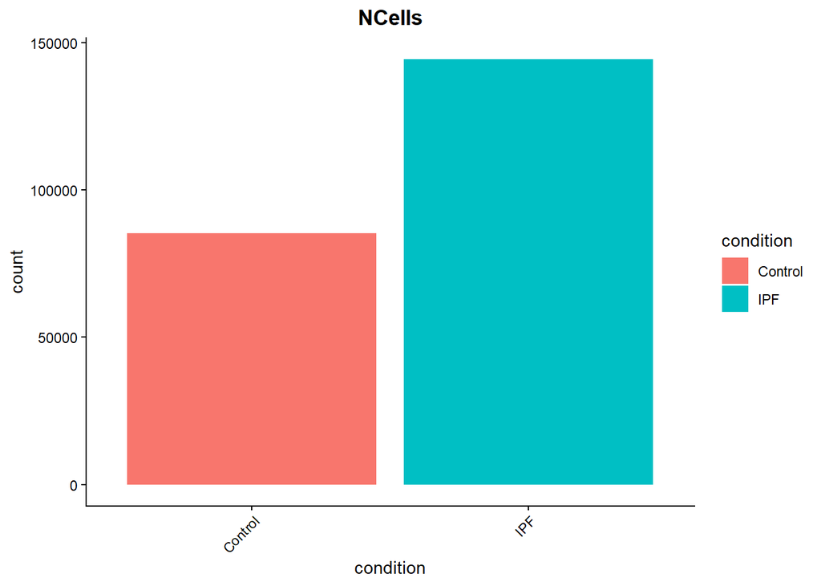

```r
# Get sample metadata from Seurat object.
meta <- subset_obj@meta.data

# Visualize cell counts.
meta %>%
  ggplot(aes(x = condition, fill = condition)) +
  geom_bar() +
  theme_classic() +
  theme(axis.text.x = element_text(angle = 45, vjust = 1, hjust = 1)) +
  theme(plot.title = element_text(hjust = 0.5, face = "bold")) +
  ggtitle("NCells")
```

### Step 2.2: Visualize UMI distribution across conditions

UMI counts should generally be above 500. If UMI counts are between 500 and 1000, the cells should probably be sequenced more deeply.

Note: Most are above 1000 so good sequencing depth.

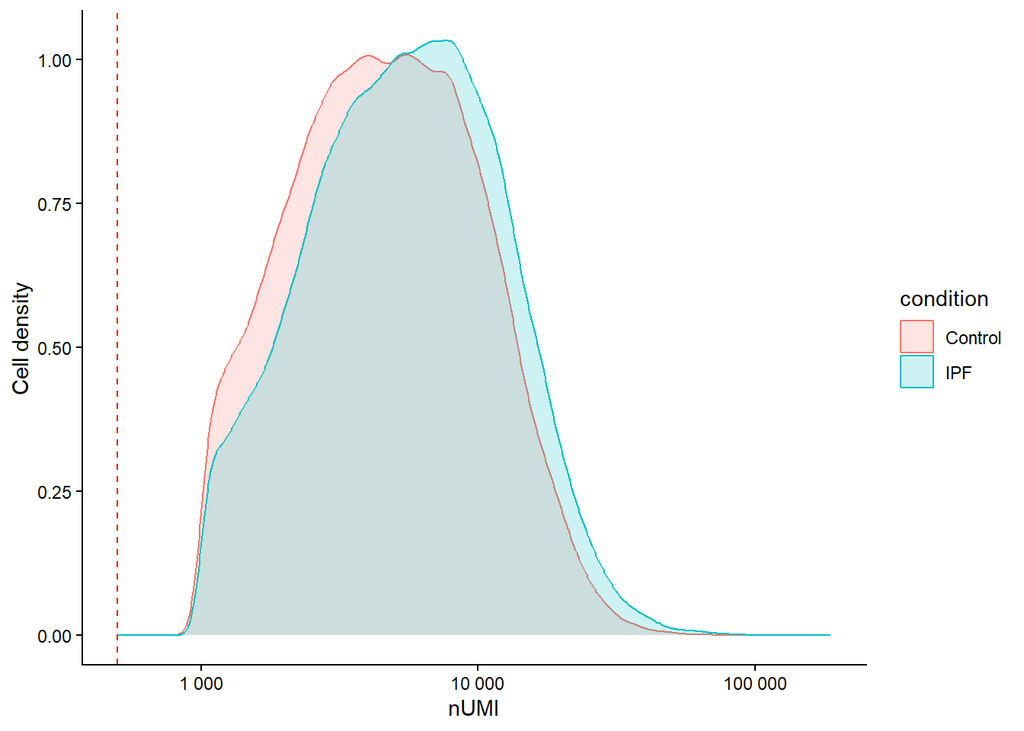

```r
# Visualize UMI counts per cell.
meta %>%
  ggplot(aes(x = nUMI, color = condition, fill = condition)) +
  geom_density(alpha = 0.2) +
  scale_x_log10(labels = label_number()) +
  ylab("Cell density") +
  geom_vline(xintercept = 500, linetype = "dashed", color = "red") +
  theme_classic()
```

### Step 2.3: Visualize cell novelty score

Cells with novelty score above 0.80 are considered good quality cells.

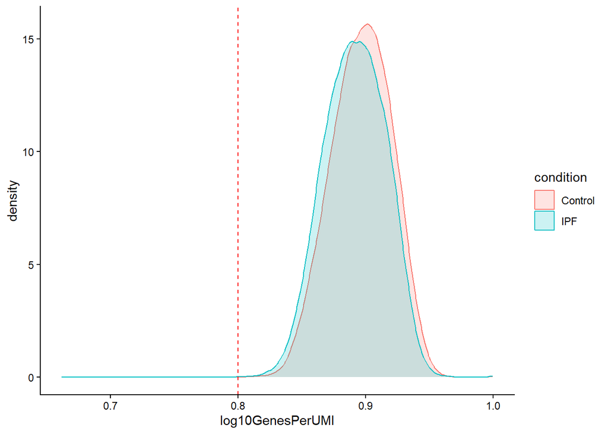

```r
# Visualize novelty score.
meta %>%
  ggplot(aes(x = log10GenesPerUMI, color = condition, fill = condition)) +
  geom_density(alpha = 0.2) +
  geom_vline(xintercept = 0.8, linetype = "dashed", color = "red") +
  theme_classic()
```

### Step 2.4: Visualize mito ratio

Low quality cells have mitochondrial ratio higher than 0.20.

Note: All cells below mito ratio of 0.20.

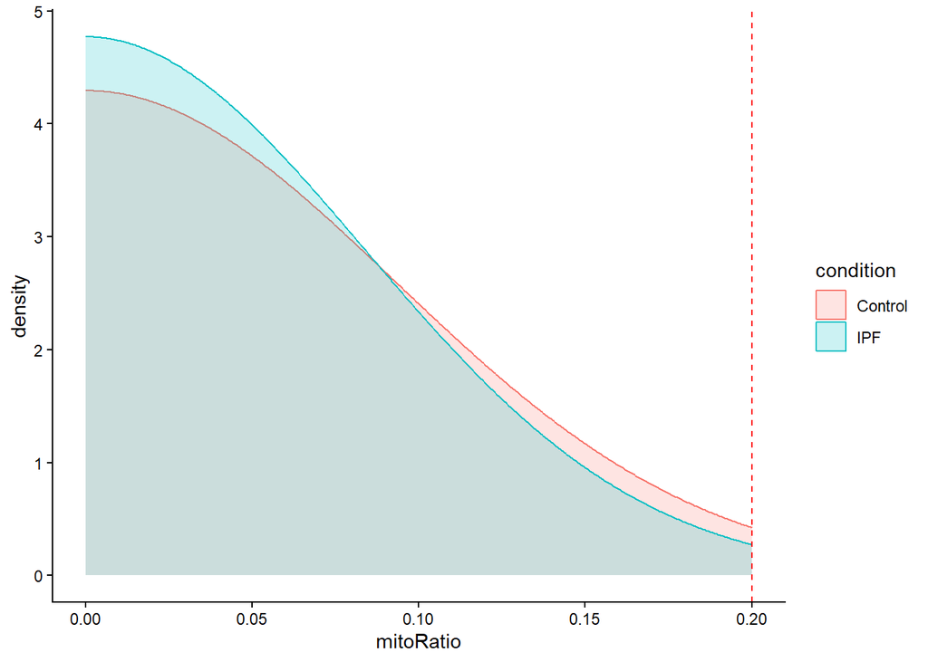

```r
# Visualize mitochondrial ratio.
meta %>%
  ggplot(aes(x = mitoRatio, color = condition, fill = condition)) +
  geom_density(alpha = 0.2) +
  geom_vline(xintercept = 0.2, linetype = "dashed", color = "red") +
  theme_classic()
```

### Step 2.5: Visualize joint filtering effects

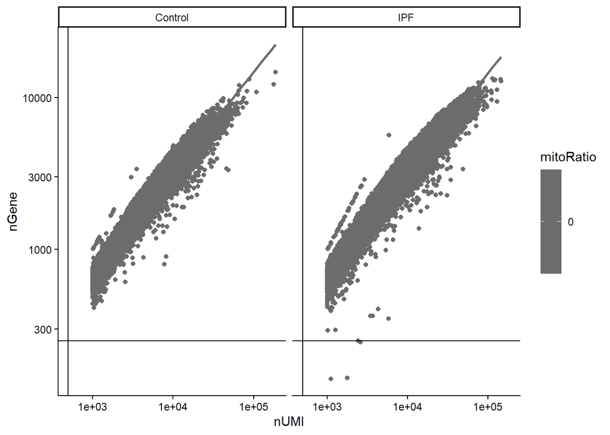

```r
# Visualize joint filtering QCs.
meta %>%
    ggplot(aes(x = nUMI, y = nGene, color = mitoRatio)) +
    geom_point() +
    scale_colour_gradient(low = "gray90", high = "black") +
    stat_smooth(method = lm) +
    scale_x_log10() +
    scale_y_log10() +
    geom_vline(xintercept = 500) +
    geom_hline(yintercept = 250) +
    theme_classic() +
    facet_wrap(~condition)
```

### Step 2.6: Visualize valid cells with knee plot

A distinct “cliff-and-knee” shape indicates a healthy sample with clear separation between true cells and background “empty” droplets, while other shapes can point to issues with sample quality.

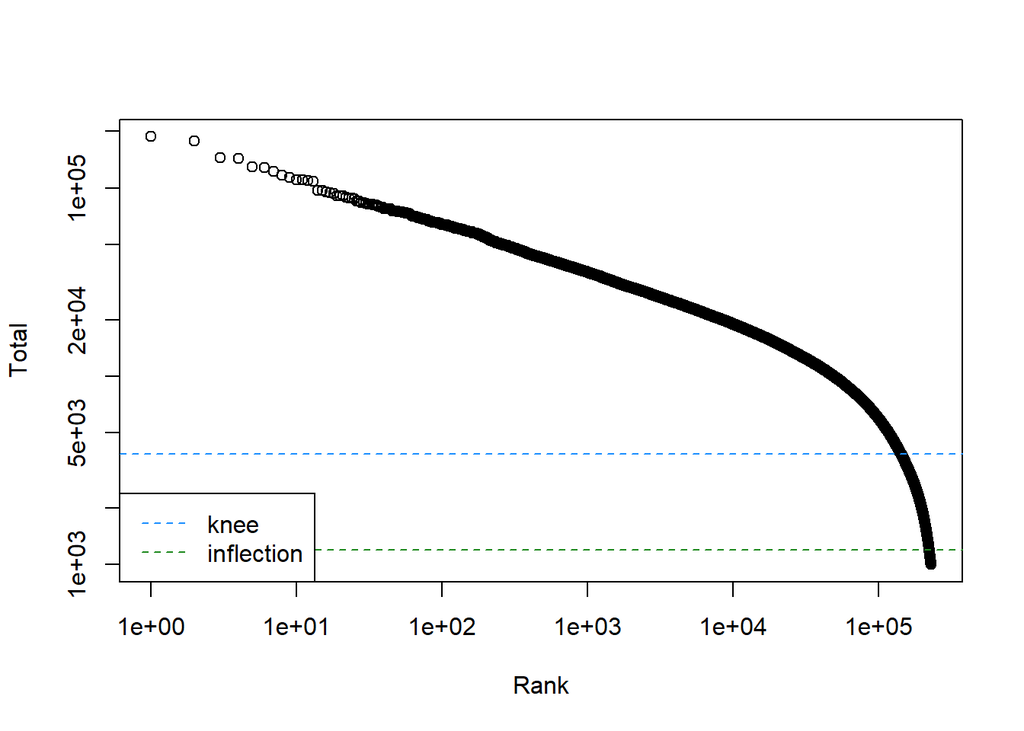

```r
# Rank expression barcodes.
br.out = barcodeRanks(subset_obj@assays$RNA$counts)

# Plot knee plot.
plot(br.out$rank, br.out$total, log = "xy", xlab = "Rank", ylab = "Total")
abline(h = metadata(br.out)$knee, col = "dodgerblue", lty = 2)
abline(h = metadata(br.out)$inflection, col = "forestgreen", lty = 2)
legend("bottomleft", lty = 2, col = c("dodgerblue", "forestgreen"), legend = c("knee", "inflection"))
```

```r
# Remove unneeded objects.
rm(br.out, meta)
```

### Step 2.7: Filtering

#### Step 2.7.1: Cell-level filtering

We will filter the cells based on the following thresholds:

nUMI > 500

nGene > 250

log10GenesPerUMI > 0.8

mitoRatio < 0.2

```r
# Get pre-filtering cell counts.
dim(subset_obj)[2] # 229,720 cells
```

```
## [1] 229720
```

```r
# Low-quality cell filtering.
umi_filtered <- subset(x = subset_obj, subset = nUMI >= 500)
gene_filtered <- subset(x = umi_filtered, subset = nGene >= 250)
genesperumi_filtered <- subset(x = gene_filtered, subset = log10GenesPerUMI > 0.80)
mitoratio_filtered <- subset(x = genesperumi_filtered, subset = mitoRatio < 0.20)

# Get post-filtering Seurat object.
# Enter level of filtering desired here.
cell_filtered_seurat = mitoratio_filtered

# Get counts after low-quality cell filtering.
dim(cell_filtered_seurat)[2] # 229,654 cells.
```

```
## [1] 229654
```

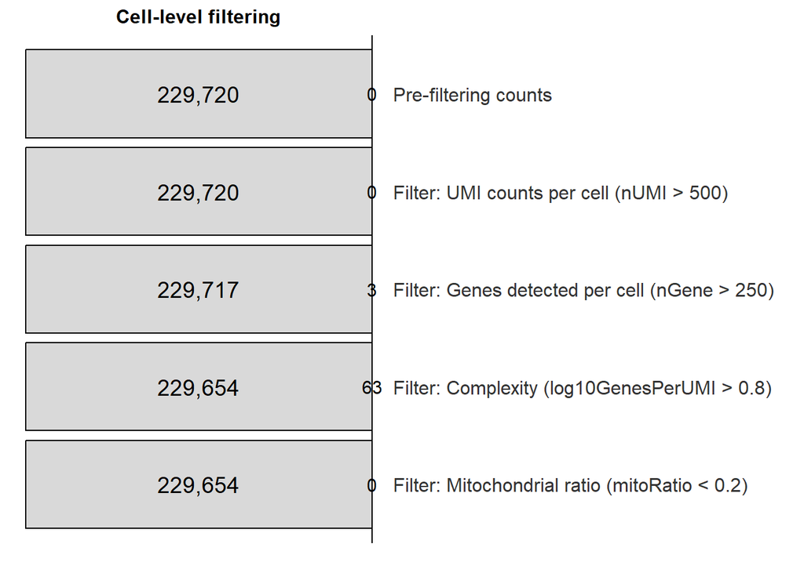

```r
# Remove unneeded objects.
rm(subset_obj, filtering_summary, gene_filtered, genesperumi_filtered, mitoratio_filtered, umi_filtered)
```

#### Step 2.7.2: Gene-level filtering

```r
# Extract count matrix.
counts <- GetAssayData(object = cell_filtered_seurat, layer = "counts")

# Get a logical vector for every gene that has more than zero counts per cell.
nonzero <- counts > 0

# Get a logical vector of genes that are expressed in 10 or more cells.
keep_genes <- Matrix::rowSums(nonzero) >= 10

# Subset counts to keep genes that are non-zero and expressed in 10 or more cells.
filtered_counts <- counts[keep_genes, ]

# Create new Seurat object with the subsetted counts.
filtered_seurat <- CreateSeuratObject(filtered_counts, meta.data = cell_filtered_seurat@meta.data)
```

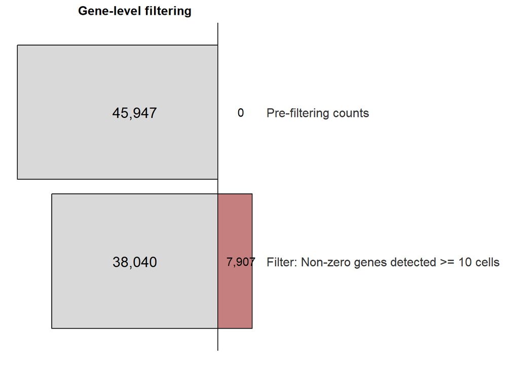

```r
# Remove unneeded objects.
rm(cell_filtered_seurat, counts, filtered_counts, filtering_summary, keep_genes, nonzero)
```

## Step 3: Normalization

### Step 3.1: Pre-normalization distribution

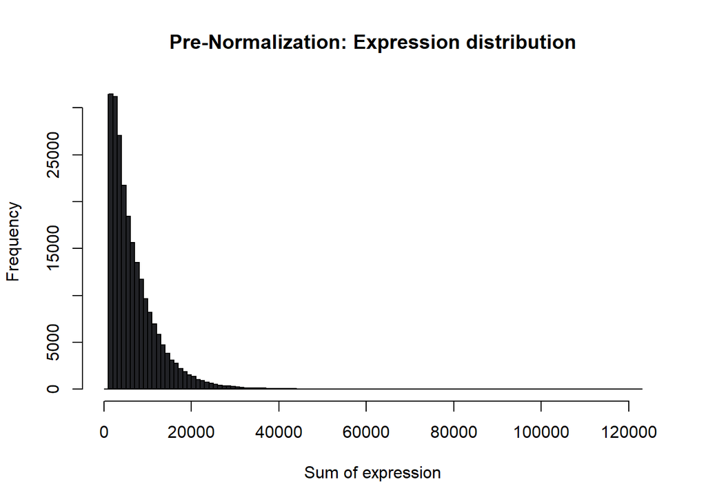

```r
# Visualize expression distribution before normalization.
hist(colSums(filtered_seurat[["RNA"]]$counts),
     breaks = 100,
     col = "#212226",
     main = "Pre-Normalization: Expression distribution",
     xlab = "Sum of expression")
```

### Step 3.2: SCTransformation

```r
# Free up memory.
gc()
```

```
##             used   (Mb) gc trigger    (Mb)   max used    (Mb)
## Ncells  16781652  896.3   29317804  1565.8   29317804  1565.8
## Vcells 833727696 6360.9 4253469883 32451.4 5110300608 38988.5
```

```r
# Set memory limit.
options(future.globals.maxSize = 5000 * 1024^2)

# Perform SCTransform normalization.
seurat_sct <- SCTransform(filtered_seurat,
                          vars.to.regress = c("mitoRatio"),
                          vst.flavor = "v2",
                          conserve.memory = TRUE,
                          verbose = FALSE)
```

```
## Will not return corrected UMI because residual type is not set to 'pearson'
```

```r
# Compare the objects before and after SCT transformation.
filtered_seurat # Look at the feature counts before transformation.
```

```
## An object of class Seurat
## 38040 features across 229654 samples within 1 assay
## Active assay: RNA (38040 features, 0 variable features)
##  1 layer present: counts
```

```r
seurat_sct # Look at the feature counts after transformation.
```

```
## An object of class Seurat
## 76080 features across 229654 samples within 2 assays
## Active assay: SCT (38040 features, 3000 variable features)
##  3 layers present: counts, data, scale.data
##  1 other assay present: RNA
```

```r
# Check which objects are stored in which assays.
seurat_sct@assays
```

```
## $RNA
## Assay (v5) data with 38040 features for 229654 cells
## First 10 features:
##  TSPAN6, TNMD, DPM1, SCYL3, C1orf112, FGR, CFH, FUCA2, GCLC, NFYA
## Layers:
##  counts
##
## $SCT
## SCTAssay data with 38040 features for 229654 cells, and 1 SCTModel(s)
## Top 10 variable features:
##  SFTPC, SCGB3A1, SCGB1A1, CCL21, SFTPA1, SCGB3A2, SFTPA2, SPP1, SFTPB,
## COL1A1
```

```r
# Remove unneeded objects.
rm(filtered_seurat)
```

### Step 3.3: Post-normalization distribution

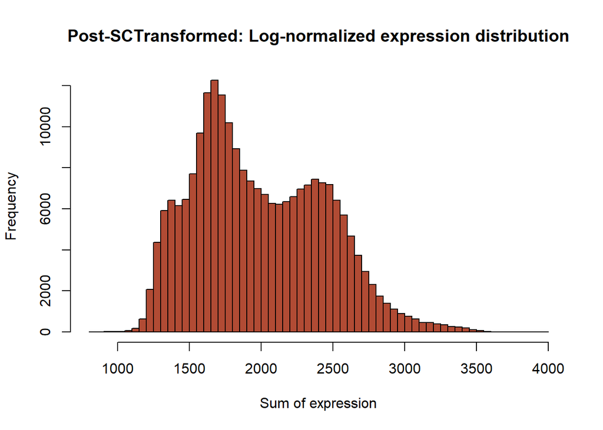

```r
# Visualize expression distribution after scaling.
hist(colSums(seurat_sct[["SCT"]]$data),
     breaks = 100,
     col = "#b14b34",
     main = "Post-SCTransformed: Log-normalized expression distribution",
     xlab = "Sum of expression")
```

## Step 4: Dimensional Reduction and Clustering

### Step 4.1: Run PCA

Note: PC15 describes approximately 50% cumulative variation in the data. The elbow plot bends at approximately PC30, which describes approximately 75% cumulative variation. For now, we will run UMAP with these 30 PCS included since this is also the Seurat default.

```r
# Run PCA.
seurat_sct <- RunPCA(seurat_sct, verbose = FALSE)

# Visualize PC dimensions with elbow plot.
# Determine percent of variation associated with each PC.
pct <- seurat_sct[["pca"]]@stdev / sum(seurat_sct[["pca"]]@stdev) * 100

# Calculate cumulative percents for each PC.
cumu <- cumsum(pct)

# Determine which PC exhibits cumulative percent greater than 90% and % variation associated with the PC as less than 5.
co1 <- which(cumu > 90 & pct < 5)[1]
co1
```

```
## [1] 41
```

```r
# Determine the difference between variation of PC and subsequent PC.
co2 <- sort(which((pct[1:length(pct) - 1] - pct[2:length(pct)]) > 0.1), decreasing = T)[1] + 1

# Last point where change of % of variation is more than 0.1%.
co2
```

```
## [1] 14
```

```r
# Minimum of the two calculation.
pcs <- min(co1, co2)
pcs
```

```
## [1] 14
```

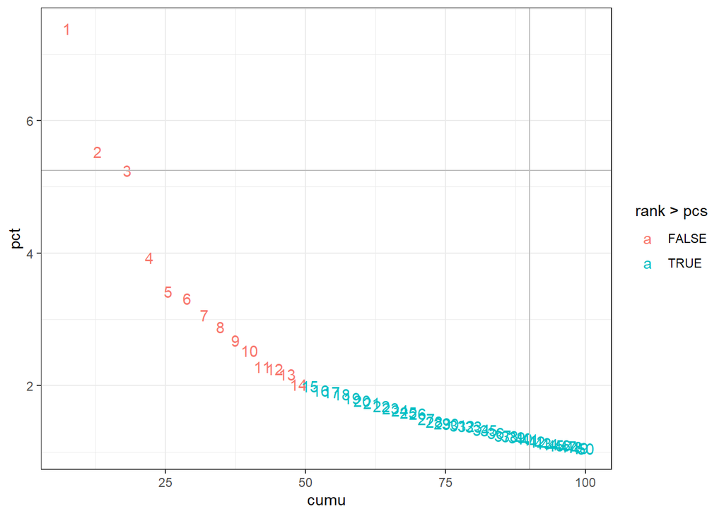

```r
# Create a dataframe with values.
elbowplot_df <- data.frame(pct = pct,
                           cumu = cumu,
                           rank = 1:length(pct))

# Elbow plot to visualize.
ggplot(elbowplot_df, aes(cumu, pct, label = rank, color = rank > pcs)) +
  geom_text() +
  geom_vline(xintercept = 90, color = "grey") +
  geom_hline(yintercept = min(pct[pct > 5]), color = "grey") +
  theme_bw()
```

```r
# Remove unneeded objects.
rm(co1, co2, cumu, elbowplot_df, pcs, pct)
```

### Step 4.2: Run UMAP

```r
# Visualize dimension reduction from PCA.
seurat_sct <- RunUMAP(seurat_sct, dims = 1:30, reduction = "pca")
```

[output not shown]

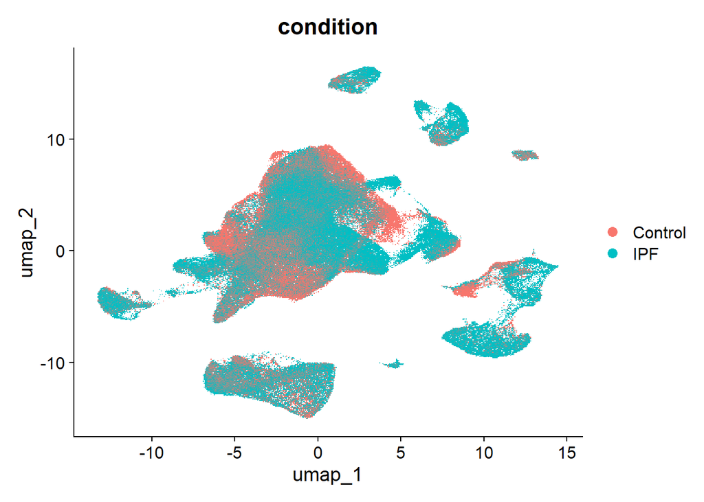

```r
DimPlot(object = seurat_sct, group.by = "condition")
```

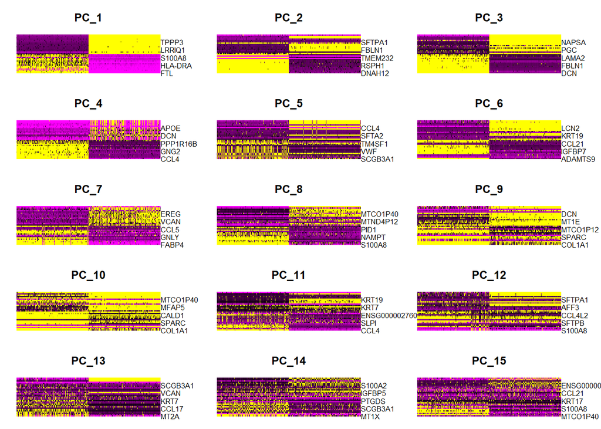

```r
# Explore the top PC markers.
DimHeatmap(seurat_sct,
           dims = 1:15,
           cells = 500,
           balanced = TRUE)
```

### Step 4.3: Compute KNN

```r
# Compute SNN graph.
seurat_cluster <- FindNeighbors(object = seurat_sct, dims = 1:30) # Based on elbow plot.
# Remove unneeded objects.
rm(seurat_sct)
```

### Step 4.4: Explore cluster resolutions

Note: Resolution at around 0.8 looks stable.

```r
# Determine start and end resolution range.
start_reso_range = 0.6
end_reso_range = 1.2
range_interval = 0.2

# Find clusters given the range.
seurat_cluster <- FindClusters(object = seurat_cluster,
                               resolution = seq(from = start_reso_range,
                                                to = end_reso_range,
                                                by = range_interval))
```

```
## Modularity Optimizer version 1.3.0 by Ludo Waltman and Nees Jan van Eck
##
## Number of nodes: 229654
## Number of edges: 7130013
##
## Running Louvain algorithm...
## Maximum modularity in 10 random starts: 0.9197
## Number of communities: 29
## Elapsed time: 171 seconds
## Modularity Optimizer version 1.3.0 by Ludo Waltman and Nees Jan van Eck
##
## Number of nodes: 229654
## Number of edges: 7130013
##
## Running Louvain algorithm...
## Maximum modularity in 10 random starts: 0.9106
## Number of communities: 36
## Elapsed time: 148 seconds
## Modularity Optimizer version 1.3.0 by Ludo Waltman and Nees Jan van Eck
##
## Number of nodes: 229654
## Number of edges: 7130013
##
## Running Louvain algorithm...
## Maximum modularity in 10 random starts: 0.9031
## Number of communities: 40
## Elapsed time: 127 seconds
## Modularity Optimizer version 1.3.0 by Ludo Waltman and Nees Jan van Eck
##
## Number of nodes: 229654
## Number of edges: 7130013
##
## Running Louvain algorithm...
## Maximum modularity in 10 random starts: 0.8968
## Number of communities: 42
## Elapsed time: 124 seconds
```

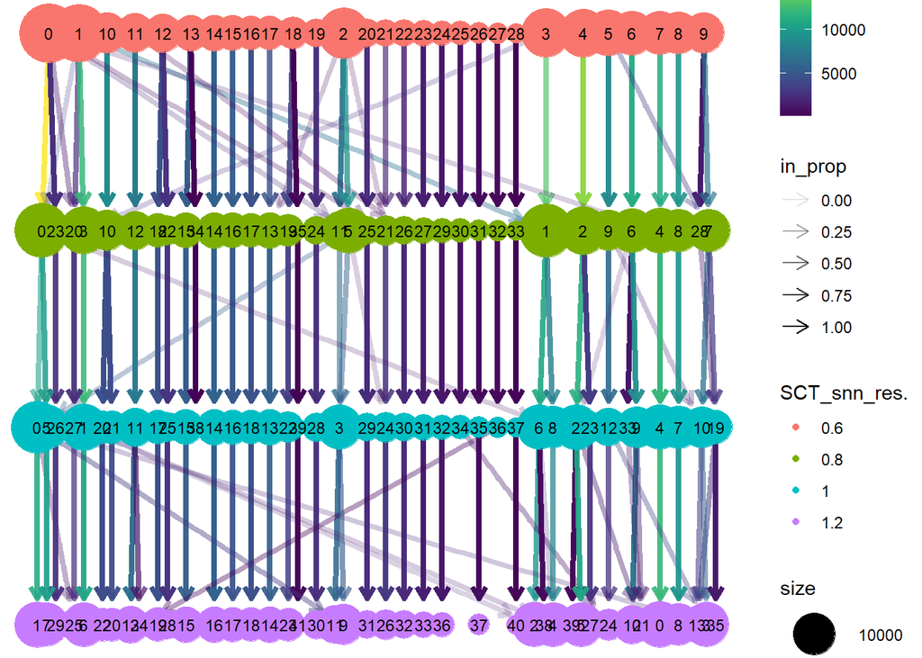

```r
# Remove unneeded objects.
rm(start_reso_range, end_reso_range, range_interval)

# Visualize relationship between different cluster resolutions using clustree.
clustree(seurat_cluster)
```

### Step 4.5: Choose cluster resolution

Note: Resolution at around 0.8 looks stable based on clustree above.

```
## Rasterizing points since number of points exceeds 100,000.
## To disable this behavior set `raster=FALSE`
```

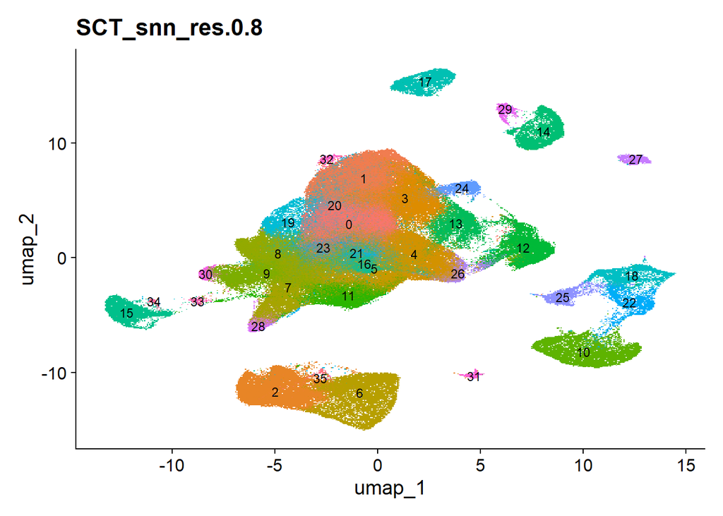

```r
# Assign desired cluster resolution as identity of Seurat.
Idents(object = seurat_cluster) <- "SCT_snn_res.0.8"

# Visualize cluster with a UMAP.
DimPlot(seurat_cluster,
        reduction = "umap",
        label = TRUE,
        label.size = 3) +
  ggtitle("SCT_snn_res.0.8") +
  NoLegend()
```

## Step 5: Cell Type Annotation

### Step 5.1: Find top markers associated with each cluster

```r
# Find markers for every cluster compared to all remaining cells. Include only positive markers.
cluster_markers <- FindAllMarkers(seurat_cluster, only.pos = TRUE)
datatable(
  cluster_markers %>%
    group_by(cluster) %>%
    dplyr::filter(avg_log2FC > 1) %>%
    slice_max(order_by = p_val_adj, n = 10, with_ties = FALSE) %>%
    arrange(cluster, p_val_adj),
  caption = "Top 10 highly differential markers by cluster",
  options = list(pageLength = 10, scrollX = TRUE),
  rownames = FALSE
) %>%
  formatRound(columns = c("avg_log2FC"), digits = 3) %>%
  formatSignif(columns = c("p_val"), digits = 3) %>%
  formatSignif(columns = c("p_val_adj"), digits = 3)
```

| p_val | avg_log2FC | pct.1 | pct.2 | p_val_adj | cluster | gene |
| --- | --- | --- | --- | --- | --- | --- |
| 1.764201722939756e-39 | 1.333923779699488 | 0.01 | 0.004 | 6.711023354062831e-35 | 0 | BTF3P7 |
| 5.301487937538782e-39 | 1.063485219978604 | 0.015 | 0.007 | 2.016686011439752e-34 | 0 | ENSG00000213080 |
| 3.97688718090631e-34 | 1.054644962388758 | 0.013 | 0.006 | 1.51280788361676e-29 | 0 | ENSG00000254054 |
| 4.809677541510539e-34 | 1.024548537642625 | 0.014 | 0.007 | 1.829601336790609e-29 | 0 | TIGD2 |
| 6.535309817076322e-33 | 1.303850676797611 | 0.011 | 0.005 | 2.486031854415833e-28 | 0 | ENSG00000279905 |
| 1.309422100680127e-32 | 1.157098669574312 | 0.01 | 0.004 | 4.981041670987204e-28 | 0 | ENSG00000260273 |
| 4.009586359139209e-32 | 1.060207271467038 | 0.013 | 0.006 | 1.525246651016555e-27 | 0 | GSTO3P |
| 7.898347150002396e-32 | 1.086982584401441 | 0.01 | 0.004 | 3.004531255860912e-27 | 0 | CRYBB1 |
| 6.628226469617463e-25 | 1.059058068069233 | 0.01 | 0.005 | 2.521377349042483e-20 | 0 | GPR150 |
| 2.368212829722207e-19 | 1.011514923581594 | 0.01 | 0.005 | 9.008681604263276e-15 | 0 | ELANE |

[output cut: 350 more lines]

```r
# Remove unneeded objects.
rm(cluster_markers)
```

### Step 5.2: Visualize clusters against known markers

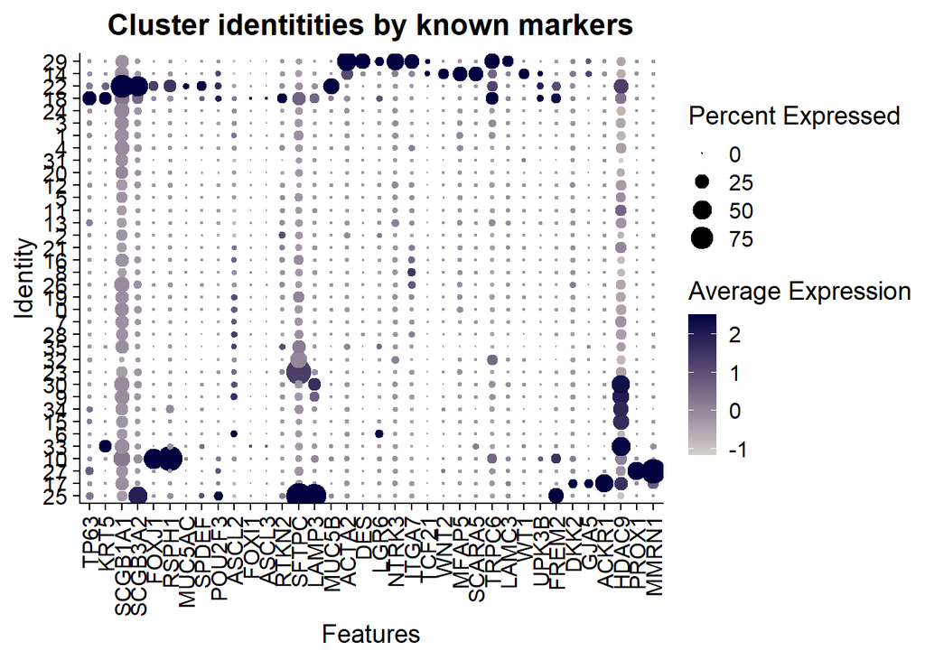

```r
# Visualize the clusters against [known markers of interest](https://pmc.ncbi.nlm.nih.gov/articles/PMC9202574/).
# Basal cells: TP63, KRT5
# Secretory cells: SCGB1A1, SCGB3A2
# Ciliated cells: FOXJ1, RSPH1
# Goblet cells: MUC5AC, SPDEF
# Tuft cells: POU2F3, ASCL2
# Ionocytes: FOXI1, ASCL3
# AT1: AGERH, RTKN2
# AT2: SFTPC, LAMP3
# Mucous cells: MUC5B, SPDEF
# Airway SMCs: ACTA2, DES, LGR6
# vSMCs: NTRK3, ITGA7
# Alveolar fibroblasts 1: TCF21, WNT2
# Alveolar fibroblasts 2: MFAP5, SCARA5
# Pericytes: TRPC6, LAMC3
# Mesothelium: WT1, UPK3B, FREM2
# Arterial endothelial cells: DKK2, GJA5
# Venous endothelial cells: ACKR1, HDAC9
# Lymphatic endothelial cells: PROX1, MMRN1
DotPlot(seurat_cluster,
        features = c("TP63", "KRT5",
                     "SCGB1A1", "SCGB3A2",
                     "FOXJ1", "RSPH1",
                     "MUC5AC", "SPDEF",
                     "POU2F3", "ASCL2",
                     "FOXI1", "ASCL3",
                     "RTKN2",
                     "SFTPC", "LAMP3",
                     "MUC5B",
                     "ACTA2", "DES", "LGR6",
                     "NTRK3", "ITGA7",
                     "TCF21", "WNT2",
                     "MFAP5", "SCARA5",
                     "TRPC6", "LAMC3",
                     "WT1", "UPK3B", "FREM2",
                     "DKK2", "GJA5",
                     "ACKR1", "HDAC9",
                     "PROX1", "MMRN1"),
        cluster.idents = TRUE,
        cols = c("#d6cfc7", "#01013f"),
        dot.scale = 6,
        scale.by = "size") +
  ggtitle("Cluster identitities by known markers") +
  theme(plot.title = element_text(hjust = 0.5),
        axis.text.x = element_text(angle = 90, vjust = 0.5, hjust = 1))
```

### Step 5.3: Run Azimuth annotation

Note: Prediction score is high across the board for all cell types.

```r
# Check all available Azimuth references.
available_data <- AvailableData()
available_data[grep("lung", available_data[, 3]), 1:3] # Use lungref.
```

```
##                    Dataset Version                 Summary
## lungref.SeuratData lungref   2.0.0 Azimuth Reference: lung
```

```r
# Run Azimuth with lungref.
options(timeout = 1000)
seurat_annotated <- RunAzimuth(seurat_cluster, reference = "lungref")
```

```
## detected inputs from HUMAN with id type Gene.name
```

```
## reference rownames detected HUMAN with id type Gene.name
```

```
## Normalizing query using reference SCT model
```

```
## Only one SCT model detected; no need to select.
```

```
## Projecting cell embeddings
```

```
## Finding query neighbors
```

```
## Finding neighborhoods
```

```
## Finding anchors
```

```
##  Found 88637 anchors
```

```
## Finding integration vectors
```

```
## Finding integration vector weights
```

```
## Predicting cell labels
## Predicting cell labels
## Predicting cell labels
## Predicting cell labels
## Predicting cell labels
## Predicting cell labels
```

```
##
## Integrating dataset 2 with reference dataset
```

```
## Finding integration vectors
```

```
## Integrating data
```

```
## Running UMAP projection
```

```
## 03:02:57 Processing block 1 of 1
```

```
## 03:03:57 Finished
```

[output not shown]

```
## Rasterizing points since number of points exceeds 100,000.
## To disable this behavior set `raster=FALSE`
```

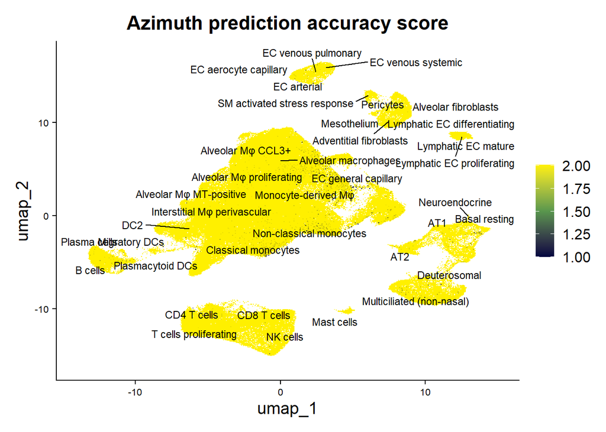

```r
# Check annotation accuracy.
Idents(seurat_annotated) <- "predicted.ann_finest_level"
FeaturePlot(
  seurat_annotated,
  features = "mapping.score",
  cols = c("#01013f", "#59974d", "#fff000"),
  label = TRUE,
  label.size = 3,
  repel = TRUE,
  label.color = "black"
) +
  theme(axis.text.x = element_text(size = 8),
        axis.text.y = element_text(size = 8)) +
  ggtitle("Azimuth prediction accuracy score")
```

```r
# Remove unneeded object.
rm(available_data, seurat_cluster)
```

### Step 5.4: Collapse similar cell type groups

```r
# Find unique identified cell types.
seurat_annotated$cell_type = seurat_annotated$predicted.ann_finest_level
unique(seurat_annotated$cell_type)
```

```
##  [1] "Classical monocytes"          "Alveolar macrophages"
##  [3] "CD8 T cells"                  "Non-classical monocytes"
##  [5] "Lymphatic EC mature"          "Monocyte-derived Mφ"
##  [7] "Adventitial fibroblasts"      "AT1"
##  [9] "Alveolar fibroblasts"         "CD4 T cells"
## [11] "DC2"                          "NK cells"
## [13] "B cells"                      "Interstitial Mφ perivascular"
## [15] "EC venous pulmonary"          "EC general capillary"
## [17] "Alveolar Mφ proliferating"    "Basal resting"
## [19] "EC arterial"                  "Multiciliated (non-nasal)"
## [21] "Transitional Club-AT2"        "Plasma cells"
## [23] "Lymphatic EC differentiating" "Pericytes"
## [25] "AT2"                          "Club (non-nasal)"
## [27] "EC venous systemic"           "Deuterosomal"
## [29] "Plasmacytoid DCs"             "Mesothelium"
## [31] "T cells proliferating"        "Ionocyte"
## [33] "Smooth muscle"                "Mast cells"
## [35] "EC aerocyte capillary"        "Alveolar Mφ CCL3+"
## [37] "Peribronchial fibroblasts"    "Migratory DCs"
## [39] "Suprabasal"                   "Goblet (nasal)"
## [41] "SMG duct"                     "Fibromyocytes"
## [43] "SM activated stress response" "Alveolar Mφ MT-positive"
## [45] "Myofibroblasts"               "Neuroendocrine"
## [47] "Club (nasal)"                 "AT2 proliferating"
## [49] "Goblet (bronchial)"           "Lymphatic EC proliferating"
```

```r
# Collapse all the endothelial cells.
grep("EC", seurat_annotated$cell_type, value = TRUE) %>% unique()
```

```
## [1] "Lymphatic EC mature"          "EC venous pulmonary"
## [3] "EC general capillary"         "EC arterial"
## [5] "Lymphatic EC differentiating" "EC venous systemic"
## [7] "EC aerocyte capillary"        "Lymphatic EC proliferating"
```

```r
seurat_annotated@meta.data <- mutate(seurat_annotated@meta.data,
                                     cell_type =
                                       recode(cell_type,
                                              "EC arterial" = "Endothelial",
                                              "EC venous pulmonary" = "Endothelial",
                                              "EC general capillary" = "Endothelial",
                                              "EC venous systemic" = "Endothelial",
                                              "EC aerocyte capillary" = "Endothelial",
                                              "Lymphatic EC mature" = "Lymphatic EC",
                                              "Lymphatic EC differentiating" = "Lymphatic EC",
                                              "Lymphatic EC proliferating" = "Lymphatic EC"))

# Collapse all the fibroblasts.
grep("fibroblast", seurat_annotated$cell_type, value = TRUE) %>% unique()
```

```
## [1] "Adventitial fibroblasts"   "Alveolar fibroblasts"
## [3] "Peribronchial fibroblasts" "Myofibroblasts"
```

```r
seurat_annotated@meta.data <- mutate(seurat_annotated@meta.data,
                                     cell_type =
                                       recode(cell_type,
                                              "Adventitial fibroblasts" = "Fibroblasts",
                                              "Alveolar fibroblasts" = "Fibroblasts",
                                              "Peribronchial fibroblasts" = "Fibroblasts"))

# Collapse all the immune cells.
seurat_annotated$cell_type[seurat_annotated$predicted.ann_level_1 == "Immune"] %>% unique()
```

```
##  [1] "Classical monocytes"          "Alveolar macrophages"
##  [3] "CD8 T cells"                  "Non-classical monocytes"
##  [5] "Monocyte-derived Mφ"          "CD4 T cells"
##  [7] "DC2"                          "NK cells"
##  [9] "B cells"                      "Interstitial Mφ perivascular"
## [11] "Endothelial"                  "Alveolar Mφ proliferating"
## [13] "Plasma cells"                 "Plasmacytoid DCs"
## [15] "AT1"                          "T cells proliferating"
## [17] "Mast cells"                   "Alveolar Mφ CCL3+"
## [19] "Migratory DCs"                "Goblet (nasal)"
## [21] "Club (non-nasal)"             "Alveolar Mφ MT-positive"
## [23] "Basal resting"                "Ionocyte"
## [25] "Fibroblasts"                  "Multiciliated (non-nasal)"
## [27] "AT2"                          "Lymphatic EC"
## [29] "AT2 proliferating"            "Club (nasal)"
```

```r
seurat_annotated@meta.data <- mutate(seurat_annotated@meta.data,
                                     cell_type =
                                       recode(cell_type,
                                              "Classical monocytes" = "Immune",
                                              "Alveolar macrophages" = "Immune",
                                              "CD8 T cells" = "Immune",
                                              "Non-classical monocytes" = "Immune",
                                              "Monocyte-derived Mφ" = "Immune",
                                              "CD4 T cells" = "Immune",
                                              "DC2" = "Immune",
                                              "NK cells" = "Immune",
                                              "B cells" = "Immune",
                                              "Interstitial Mφ perivascular" = "Immune",
                                              "Alveolar Mφ proliferating" = "Immune",
                                              "Plasma cells" = "Immune",
                                              "Plasmacytoid DCs" = "Immune",
                                              "T cells proliferating" = "Immune",
                                              "Alveolar Mφ CCL3+" = "Immune",
                                              "Migratory DCs" = "Immune",
                                              "Alveolar Mφ MT-positive" = "Immune"))
```

### Step 5.5: Visualize finalized cell type annotation

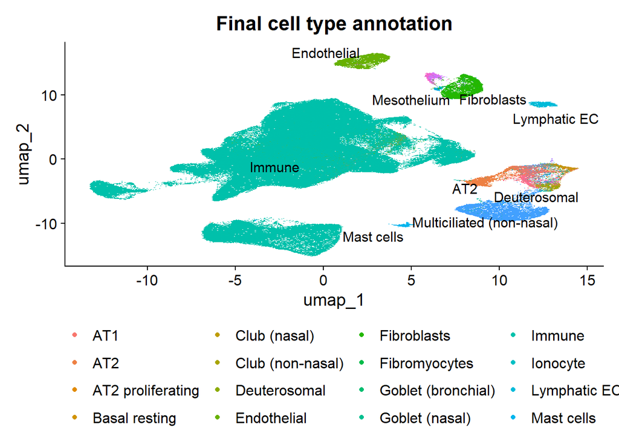

```r
 # Visualize finalized annotation with a UMAP.
DimPlot(seurat_annotated,
        reduction = "umap",
        group.by = "cell_type",
        label = TRUE,
        label.size = 4,
        repel = TRUE) +
  ggtitle("Final cell type annotation") +
  theme(plot.title = element_text(hjust = 0.5),
        legend.position = "bottom",
        legend.spacing.x = unit(0.2, "cm"),
        legend.spacing.y = unit(0.1, "cm")) +
  guides(colour = guide_legend(nrow = 4))
```

## Step 6: Save Seurat Object

```r
# Save Seurat object.
saveRDS(object = seurat_annotated,
        file = "Z:/Kendrix/IPF_Lung/GSE136831/processed_data/preprocessed_seurat_obj.rds")
```